# Fish and health in Finland and Porvoo: results with special focus on PFAS compounds

Jouni Tuomisto

2021-03-15

## Shortcut to model download

This is an open assessment looking at health effects of fish consumption in Finland. The details of the assessment are described at [Opasnet](http://fi.opasnet.org/fi/PFAS-yhdisteiden%20tautitaakka). This file contains the R code to run the assessment model.

This code downloads all the ovariables created by the previous code, fishhealth_initiate.Rmd, runs the model and plots various graphs and tables about the results.

These problems have been fixed:

2. Calculate total personal BoD for individuals in Porvoo and Helsinki. Do not compare those at the (Finnish) population level. DONE
3. Correct the fish intake distribution to manage dimension Area correctly. DONE
4. Check that all oapply NA-fillings are intended. DONE
5. Correct the “Kalansyönti Suomessa keskimäärin” figure. DONE
6. PFOS, PFAS: ug/g –> ng/g DONE
7. PFAS: separate Porvoo from other regions. DONE
8. NOTE! Salmon concentrations include farmed salmon at the moment. This is OK for health impact assessment. DONE
9. Is amount / Group good for fillna? check. Solution: Yes, because Inpamount does not contain Group. DONE
10. Is expo_locations still used? Yes. DONE
11. Kalansyönti väestössä: Group is not ordered correctly. DONE
12. Yhdisteiden saanti kalasta: Too many averages. Are they gender-specific? Solution: match with Area. DONE
13. Exposure to compounds: thin the Age on x axis. DONE
14. BoDattr tables: orbind the summary row to each table. DONE
15. Amount for Porvoo is too high. Why? Solution: Food causes multiplication, so clarify Inpamount. DONE
16. Hg produces NA in some cases. Why? Solution: remove rows with NA. DONE

These issues are to be fixed:

17. Abraham et al 2020 kynnystason lisäys annos-vasteeseen DONE
18. taulukko terveysvaikutuksista altisteet ja terveysvasteet DONE
19. Kuva 1: pallokuva kokonaistautitaakasta (vanha kuva 6) DONE
20. Kuva 2: ikäjakauma nettoterveysvaikutuksesta (vanha kuva 7 ilman vasteita) DONE
21. Kuva 3: Venn-kuvaaja TWI vs RDI DONE
22. Kuva 4 syönti: suomi vs Porvoo, ei sukupuolia. suomenna DONE
23. Kuva 5 PFAS-altistus Suomi, Helsinki, Porvoo DONE
24. Kuva 6 kaikkien aineiden altistus. Lisää kalan syöntisuositus. Kuva 4*2, korkeampi. suomenna DONE
25. Suomenna kaikki kuvat ja taulukot. DONE

```r
params
```

```
## $N
## [1] 200
##
## $porvoo
## [1] TRUE
```

```r
objects.latest("Op_fi5932",code_name="initiate") # [[PFAS-yhdisteiden tautitaakka]]
```

[output not shown]

[output cut: 29 more lines]

```
##   P_illness
##   PAF
##   population
##   prepare
##   RR
##   RRorig
##   showind
##   showLoctable
##   subgrouping
##   sumExposcen
##   t0.5
##   tmp
##   total_amount
##   trim
##   wiki_username
```

```r
# Update decisions and collapses so that you don't need to initiate the whole model if you build new scenarios.
dec <- opbase.data("Op_fi5932", subset="Decisions")[-1]
DecisionTableParser(dec)

CTable <- opbase.data("Op_fi5932",subset="CollapseMarginals")
if(!params$porvoo) CTable <- CTable[CTable$Variable!="expo_dir" | CTable$Function!="sample" , ]
CollapseTableParser(CTable)
CTable
```

```
##    Obs    Variable
## 1    1      amount
## 2    2         BoD
## 3    3     BoDattr
## 4    4 case_burden
## 5    5        conc
## 6    6        dose
## 7    7         ERF
## 8    8  expo_indir
## 9    9    expo_dir
## 10  10    expo_dir
## 11  11    exposure
## 12  12         PAF
## 13  13   threshold
##                                                                                                                                                                                                           Index
```

[output cut: 27 more lines]

```r
conc_eukalat <- EvalOutput(conc_eukalat)
BoDattr <- EvalOutput(BoDattr, verbose=TRUE)
```

```
##  Evaluating BoDattr ...
## - Evaluating BoD ...
## - - Evaluating incidence ...
##
##  done(0 secs)!
## - - Checking incidence marginals ... Response, Age, incidenceSource recognized as marginal(s).
## - - Processing incidence decisions ... done!
## - - Evaluating case_burden ...
##
##  done(0 secs)!
## - - Checking case_burden marginals ... Response, Gender, Iter, case_burdenSource recognized as marginal(s).
## - - Processing case_burden marginal collapses ...
```

```
##  done!
## - - Evaluating population ...
##
##  done(0 secs)!
## - - Checking population marginals ... Gender, Age, populationSource recognized as marginal(s).
##
## - done(0.36 secs)!
## - Checking BoD marginals ... Response, Age, incidenceSource, Adjust, Gender, populationSource, Iter, BoDSource recognized as marginal(s).
## - Processing BoD inputs ... done!
## - Processing BoD marginal collapses ...
```

```
##  done!
## - Processing BoD decisions ... done!
## - Evaluating PAF ...
## - - Evaluating dose ...
## - - - Evaluating exposure ...
## - - - - Evaluating expo_dir ...
## - - - - - Evaluating amount ...
##
## ----- done(0.41 secs)!
## - - - - - Checking amount marginals ... Food, Iter, Group, Fish, Gender, fish_proportionSource, amountSource recognized as marginal(s).
## - - - - - Processing amount inputs ... done!
## - - - - - Processing amount marginal collapses ...
```

```
##  done!
## - - - - - Evaluating conc ...
## - - - - - - Evaluating conc_vit ...
##
##  done(0.01 secs)!
## - - - - - - Checking conc_vit marginals ... Kala, Fish, Nutrient, Iter, conc_vitSource recognized as marginal(s).
## - - - - - - Processing conc_vit decisions ... done!
## - - - - - - Evaluating conc_poll ...
## - - - - - - - Evaluating conc_param ...
##
##  done(0 secs)!
## - - - - - - - Checking conc_param marginals ... Fish, Compound, Compound2, Parameter, Area, conc_paramSource recognized as marginal(s).
```

```
## ------ done(58.49 secs)!
## - - - - - - Checking conc_poll marginals ... Fish, Area, conc_paramSource, Iter, Source, Compound, conc_pollSource recognized as marginal(s).
## - - - - - - Evaluating conc_mehg ...
##
## ------ done(0.08 secs)!
## - - - - - - Checking conc_mehg marginals ... Area, Kala, Iter, Fish, conc_mehgSource recognized as marginal(s).
##
## ----- done(59.02 secs)!
## - - - - - Checking conc marginals ... Fish, Compound, Iter, Area, conc_paramSource, Source, concSource recognized as marginal(s).
## - - - - - Processing conc marginal collapses ...
```

```
##  done!
## - - - - - Evaluating expo_background ...
##
##  done(0 secs)!
## - - - - - Checking expo_background marginals ... Exposure_agent, Gender, Iter, expo_backgroundSource recognized as marginal(s).
## - - - - - Evaluating ERFchoice ...
##
##  done(0 secs)!
## - - - - - Checking ERFchoice marginals ... Exposure_agent, Response, Exposure, Scaling, ER_function, ERFchoiceSource recognized as marginal(s).
##
## ---- done(1.42 mins)!
## - - - - Checking expo_dir marginals ... Fish, Iter, Group, Gender, Area, Exposure_agent, concSource, Exposcen, Scaling, Age, expo_dirSource recognized as marginal(s).
## - - - - Processing expo_dir marginal collapses ...
```

```
##  done!
## - - - - Evaluating expo_indir ...
## - - - - - Processing expo_dir marginal collapses ...
```

[output not shown]

[output not shown]

```
##  done!
##
##  done(2.88 mins)!
##  Checking BoDattr marginals ... Adjust, Response, Age, Gender, Iter, Exposure_agent, Area, BoDattrSource recognized as marginal(s).
```

```r
if(FALSE) {
oprint(summary(amount,"mean"))
oprint(summary(BoD,marginals=c("Age","Response"),"mean"))
oprint(summary(BoD,marginals=c("Gender","Response"),"mean"))
summary(BoDattr)
oprint(summary(BoDattr,marginals=c("Age","Response"),"mean"))
oprint(summary(BoDattr,marginals=c("Exposure_agent","Response"),"mean"))
oprint(summary(BoDattr,marginals=c("Gender","Response"),"mean"))
oprint(summary(case_burden,"mean"))
oprint(summary(conc,"mean"))
oprint(summary(dose,"mean"))
oprint(summary(ERF,"mean"))
oprint(summary(expo_dir,"mean"))
oprint(summary(expo_dir,marginals="Exposure_agent"))
oprint(summary(expo_indir,"mean"))
oprint(summary(exposure,"mean"))
#oprint(summary(fish_proportion,"mean"))
oprint(summary(incidence,"mean"))
oprint(summary(PAF,"mean"))
oprint(summary(population,"mean"))
oprint(summary(RR,"mean"))
}
```

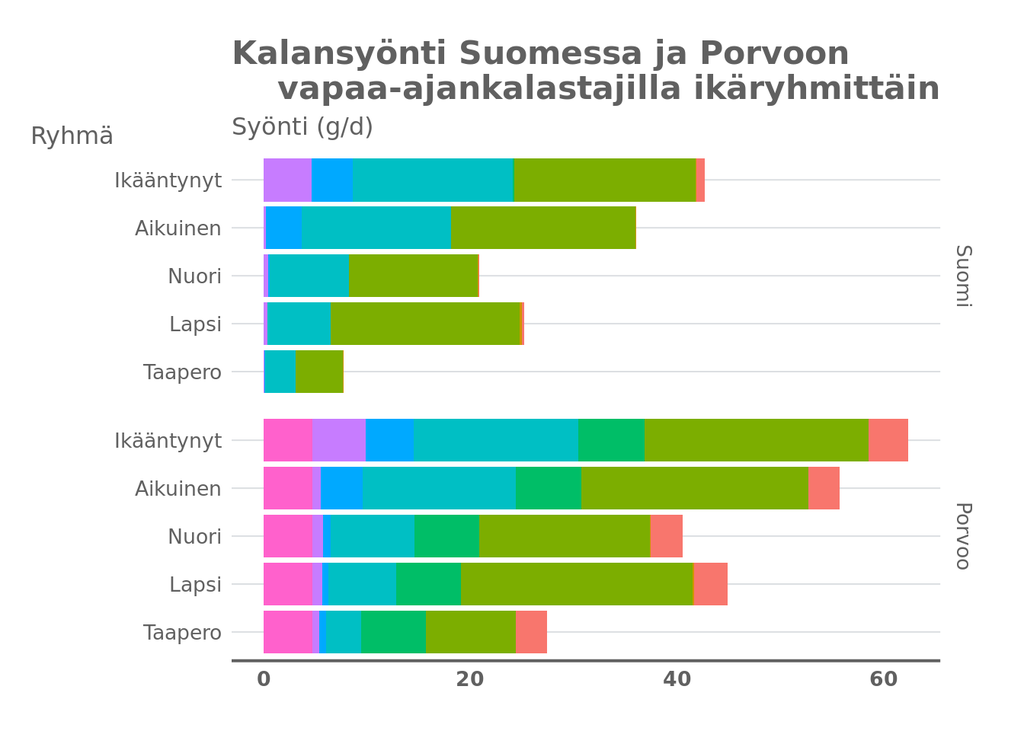

```r
###################
# Graphs
amount$Group <- factor(amount$Group, levels=c("Infants","Toddlers","Other children","Adolescents",
                                        "Adults", "Elderly"))

tmp <- oapply(amount,NULL,mean,"Gender")
tmp <- la(tmp[tmp$Area!="Helsinki",])

p <- ggplot(trim(tmp), aes(x=Ryhmä, weight=amountResult, fill=Kala))+geom_bar()+
  coord_flip()+ facet_grid(Alue ~ .)+
  thlTheme()+
  labs(
    title="Kalansyönti Suomessa ja Porvoon
    vapaa-ajankalastajilla ikäryhmittäin",
    subtitle="Syönti (g/d)"
  )
print(p)
```

```r
ggsave("Kalansyönti Suomessa ja Porvoossa ikäryhmittäin.svg")
```

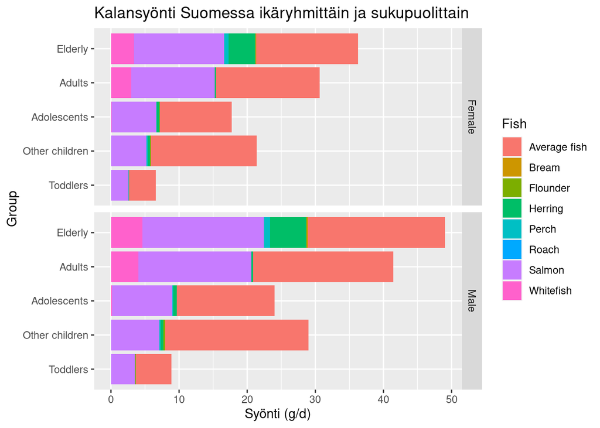

```r
p <- ggplot(trim(amount[amount$Area=="Finland",]), aes(x=Group, weight=amountResult, fill=Fish))+geom_bar()+
  coord_flip()+ facet_grid(Gender ~ .)+
  labs(
    title="Kalansyönti Suomessa ikäryhmittäin ja sukupuolittain",
    y="Syönti (g/d)"
  )
print(p)
```

```r
ggsave("Kalansyönti Suomessa ikäryhmittäin.svg")
```

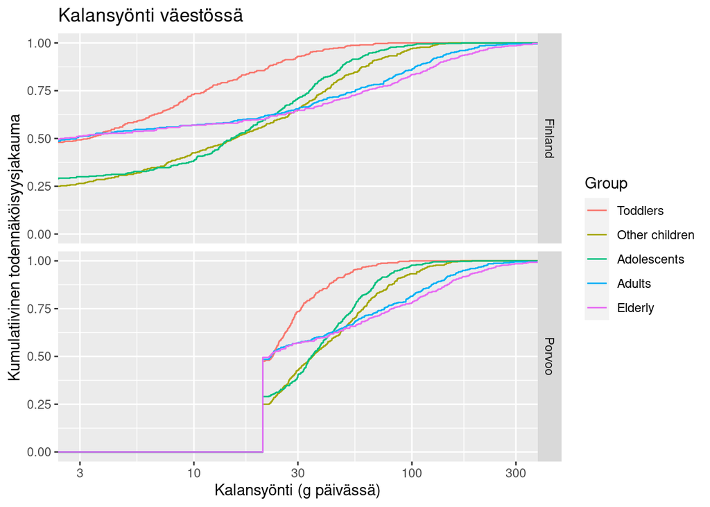

```r
tmp <- oapply(amount[amount$Area!="Helsinki",],NULL,sum,"Fish")@output
p <- ggplot(tmp, aes(x=amountResult+1, colour=Group))+stat_ecdf()+
  scale_x_log10() + facet_grid(Area~.)+
  coord_cartesian(xlim=c(3,300))+
  labs(
    title="Kalansyönti väestössä",
    x="Kalansyönti (g päivässä)",
    y="Kumulatiivinen todennäköisyysjakauma"
  )

p
```

```r
ggsave("Kalansyönnin jakauma Suomessa.svg")
```

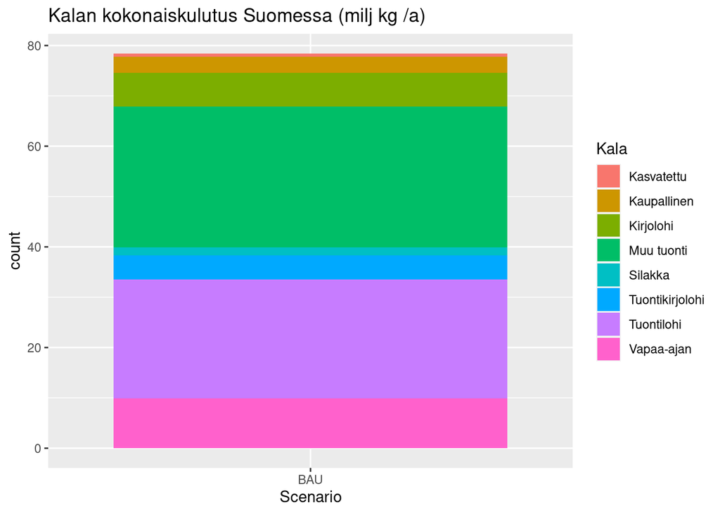

```r
ggplot(trim(EvalOutput(total_amount)), aes(x=Scenario, weight=total_amountResult, fill=Kala))+geom_bar()+
  labs(title="Kalan kokonaiskulutus Suomessa (milj kg /a)")
```

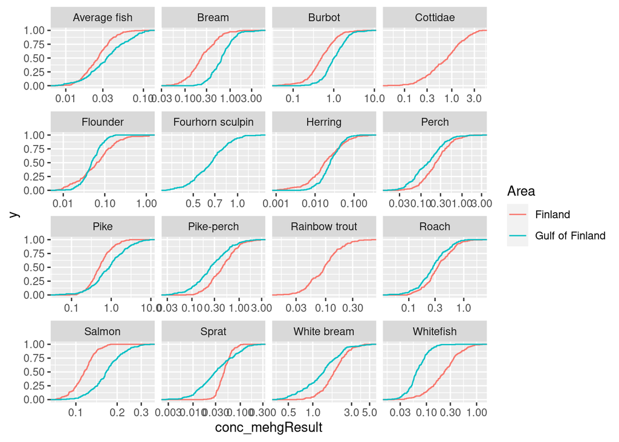

```r
ggplot(conc_mehg@output, aes(x=conc_mehgResult, colour=Area))+stat_ecdf()+
  scale_x_log10()+facet_wrap(~Fish, scales="free_x")
```

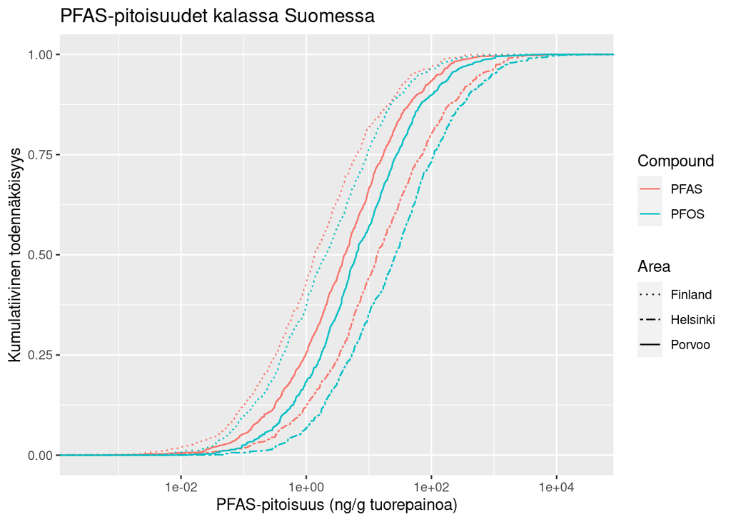

```r
ggplot(conc@output[conc$Compound %in% c("PFAS","PFOS"),], aes(x=concResult, color=Compound, linetype=Area))+stat_ecdf()+
  scale_x_log10()+
#  stat_ecdf(data=conc_eukalat@output, aes(x=conc_eukalatResult))+
  scale_linetype_manual(values=c("dotted","twodash","solid"))+
  labs(
    title="PFAS-pitoisuudet kalassa Suomessa",
    x="PFAS-pitoisuus (ng/g tuorepainoa)",
    y="Kumulatiivinen todennäköisyys"
  )
```

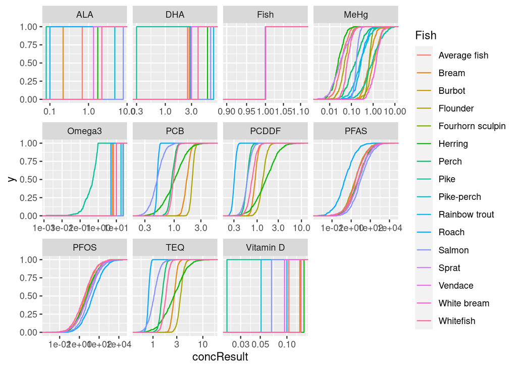

```r
# The code may produce some negative values, which are removed from the graph
ggsave("PFAS-pitoisuus kalassa Suomessa.svg")
ggplot(conc@output, aes(x=concResult, colour=Fish))+stat_ecdf()+
  facet_wrap(~Compound, scales="free_x")+scale_x_log10()
```

```r
limits <- data.frame(
  Exposure_agent = c("TEQ","MeHg","PFAS","Vitamin D","Fish"),
  Type = c("TDI","TDI","TDI","RDI","RDI"),
  Result = c(2*70/7, 1.3*70/7,4.4*70/7,10,200/7)
)

tmp <- EvalOutput(expo_dir, verbose=TRUE) # Calculated again because we want Group, which is collapsed
```

```
##  Evaluating expo_dir ...
## - Processing amount inputs ...
```

```
## - Processing amount marginal collapses ... done!
## - Processing conc marginal collapses ... done!
##
##  done(19.88 secs)!
##  Checking expo_dir marginals ... Fish, Iter, Group, Gender, Area, Exposure_agent, concSource, Exposcen, Scaling, Age, expo_dirSource recognized as marginal(s).
```

```r
tmp <- oapply(tmp,NULL,sum, c("Fish","fish_proportionSource","amountSource","concSource"))
```

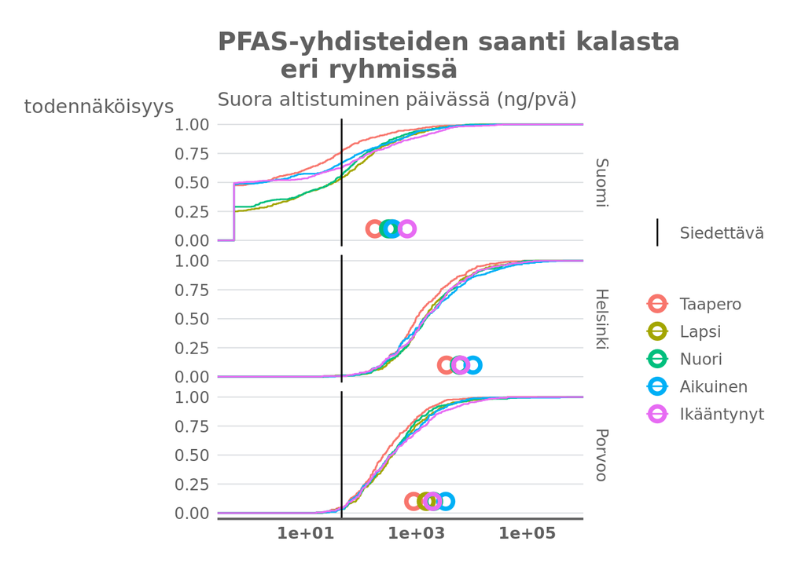

```r
tmp <- oapply(tmp,NULL,mean,"Scaling") # Not all scales are available for all Exposure agents, but all are identical
tmp <- tmp[tmp$Exposcen=="BAU" & !tmp$Exposure_agent %in% c("ALA", "EPA") , ]
tmp$Group <- factor(tmp$Group, levels=c("Toddlers","Other children","Adolescents","Adults","Elderly"))

tmp2 <- tmp[tmp$Exposure_agent=="PFAS",]
limits2 <- limits[limits$Exposure_agent=="PFAS",]
ggplot(la(tmp2@output), aes(x=expo_dirResult+0.5, colour=Ryhmä))+stat_ecdf()+
  scale_x_log10()+ facet_grid(Alue ~ .)+
  geom_vline(data=la(limits2), aes(xintercept=Result, linetype=Päiväsaanti))+
  geom_point(data = la(oapply(tmp2,c("Group","Exposure_agent","Area"),mean)@output),
             aes(x=expo_dirResult, y=0.1), shape=1, size=3, stroke=2)+
  thlTheme(legend.position = "right")+
  labs(title="PFAS-yhdisteiden saanti kalasta
       eri ryhmissä",
       subtitle="Suora altistuminen päivässä (ng/pvä)",
       y="todennäköisyys"
  )
```

```r
ggsave("PFAS-yhdisteiden saanti kalasta Suomessa ja Porvoossa.svg")
```

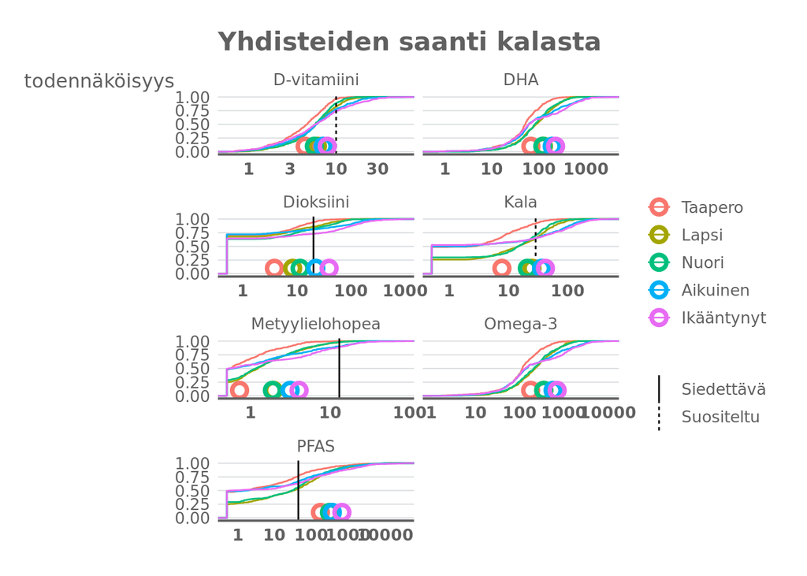

```r
tmp <- tmp[tmp$Area=="Finland",]
ggplot(la(tmp@output), aes(x=expo_dirResult+0.5, colour=Ryhmä))+stat_ecdf()+
  scale_x_log10() + facet_wrap(~Altiste, scales="free_x", ncol=2)+
  geom_vline(data=la(limits), aes(xintercept=Result, linetype=Päiväsaanti))+
  geom_point(data = la(oapply(tmp,c("Group","Exposure_agent"),mean)@output),
             aes(x=expo_dirResult, y=0.1), shape=1, size=3, stroke=2)+
  thlTheme(legend.position = "right")+
  labs(title="Yhdisteiden saanti kalasta",
       subset="Suora altistuminen päivässä (kala: g, rasvahapot: mg, D-vit: ug, PFAS: ng, TEQ: pg)",
       y="todennäköisyys")
```

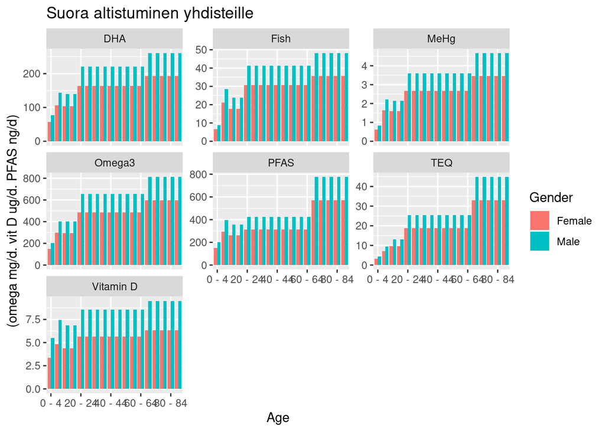

```r
ggsave("Yhdisteiden saanti kalasta Suomessa.svg", width=7, height=10)

ggplot(trim(tmp),
       aes(x=Age, weight=expo_dirResult, fill=Gender))+geom_bar(position="dodge")+
  facet_wrap(~Exposure_agent, scales="free_y")+
  scale_x_discrete(breaks = levels(ages)[seq(1,length(ages),4)])+
  labs(
    title="Suora altistuminen yhdisteille",
    y="(omega mg/d. vit D ug/d. PFAS ng/d)"
  )
```

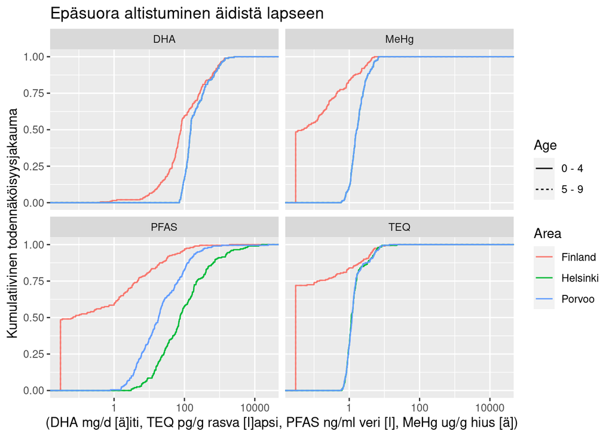

```r
ggplot(expo_indir@output[expo_indir$Exposcen=="BAU",],
       aes(x=expo_indirResult+0.03,color=Area,linetype=Age))+
  stat_ecdf()+scale_x_log10()+facet_wrap(~Exposure_agent)+
  labs(title="Epäsuora altistuminen äidistä lapseen",
       y="Kumulatiivinen todennäköisyysjakauma",
       x="(DHA mg/d [ä]iti, TEQ pg/g rasva [l]apsi, PFAS ng/ml veri [l], MeHg ug/g hius [ä])")
```

```r
ggsave("Epäsuora altistuminen äidistä lapseen.svg")
cat("Kalaperäisiä tautitaakkoja Suomessa\n")
```

```
## Kalaperäisiä tautitaakkoja Suomessa
```

```r
if(openv$N>1) {
  tmp <- summary(ERF)
  tmp <- data.frame(
    Altiste = tmp$Exposure_agent,
    Vaikutus = tmp$Response,
    Annosvastefunktio = tmp$ER_function,
    Skaalaus = tmp$Scaling,
    Havainto = tmp$Observation,
    Keskiarvo = as.character(signif(tmp$mean,2)),
    "95 luottamusväli" = paste0(signif(tmp$Q0.025,2)," - ", signif(tmp$Q0.975,2)),
    Keskihajonta = signif(tmp$sd,2)
  )#[rev(match(lev, tmp$Exposure_agent)),]

  oprint(tmp)

  tmp2 <- summary(oapply(BoDattr[BoDattr$Area=="Finland",],NULL,sum,c("Age","Gender","Exposure_agent","Response")))
  tmp2 <- data.frame(
    Alue = tmp2$Area,
    Keskiarvo = signif(tmp2$mean,2),
    "95 luottamusväli" = paste0(signif(tmp2$Q0.025,2)," - ", signif(tmp2$Q0.975,2)),
    Keskihajonta = signif(tmp2$sd,2)
  )

  tmp <- summary(oapply(BoDattr[BoDattr$Area=="Finland",],NULL,sum,c("Age","Gender")))
  tmp <- orbind(data.frame(
    Altiste = tmp$Exposure_agent,
    Vaste = tmp$Response,
#    Alue = tmp$Area,
    Keskiarvo = as.character(signif(tmp$mean,2)),
    "95 luottamusväli" = paste0(signif(tmp$Q0.025,2)," - ", signif(tmp$Q0.975,2)),
    Keskihajonta = signif(tmp$sd,2)
  ),
  data.frame(Altiste="Yhteensä", tmp2[-6])) # remove Alue

  oprint(la(tmp))

  tmp <- summary(oapply(BoDattr[BoDattr$Area=="Finland",],NULL,sum,c("Age","Gender","Response")))
  tmp <- orbind(data.frame(
    Altiste = tmp$Exposure_agent,
    Alue = tmp$Area,
    Keskiarvo = as.character(signif(tmp$mean,2)),
    "95 luottamusväli" = paste0(signif(tmp$Q0.025,2)," - ", signif(tmp$Q0.975,2)),
    Keskihajonta = signif(tmp$sd,2)
  ),
  data.frame(Altiste="Yhteensä", tmp2))

  oprint(tmp)

  tmp <- summary(oapply(BoDattr[BoDattr$Area=="Finland",],NULL,sum,c("Age","Gender","Exposure_agent")))
  tmp <- orbind(data.frame(
    Terveysvaikutus = tmp$Response,
    Alue = tmp$Area,
    Keskiarvo = signif(tmp$mean,2),
    "95 luottamusväli" = paste0(signif(tmp$Q0.025,2)," - ", signif(tmp$Q0.975,2)),
    Keskihajonta = signif(tmp$sd,2)
  ),
  data.frame(Terveysvaikutus="Yhteensä", tmp2))

  oprint((tmp))
}
```

```
##      Altiste                  Vaikutus Annosvastefunktio Skaalaus  Havainto
## 1        DHA Loss in child's IQ points               ERS     None       ERF
## 2        DHA Loss in child's IQ points               ERS     None Threshold
## 3       Fish       All-cause mortality                RR     None       ERF
## 4       Fish       All-cause mortality                RR     None Threshold
## 5       Fish                Depression                RR     None       ERF
## 6       Fish                Depression                RR     None Threshold
## 7       MeHg Loss in child's IQ points               ERS     None       ERF
## 8       MeHg Loss in child's IQ points               ERS     None Threshold
## 9     Omega3             Breast cancer                RR     None       ERF
## 10    Omega3             Breast cancer                RR     None Threshold
## 11    Omega3            CHD2 mortality     Relative Hill     None       ERF
## 12    Omega3            CHD2 mortality     Relative Hill     None Threshold
## 13      PFAS         Immunosuppression                RR    Log10       ERF
## 14      PFAS         Immunosuppression                RR    Log10 Threshold
```

[output cut: 78 more lines]

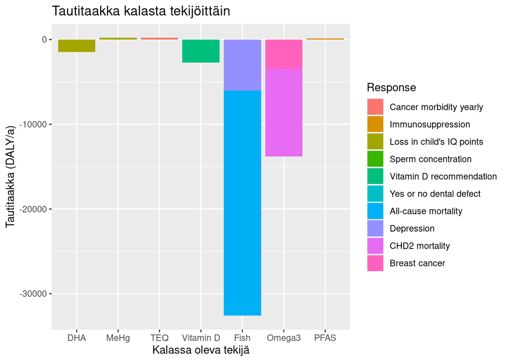

```r
tmp <- trim(BoDattr[BoDattr$Area=="Finland",])
ggplot(tmp, aes(x=Exposure_agent, weight=BoDattrResult, fill=Response),colour="black")+geom_bar()+
  labs(
    title="Tautitaakka kalasta tekijöittäin",
    x="Kalassa oleva tekijä",
    y="Tautitaakka (DALY/a)"
  )
```

```r
ggsave("Tautitaakka kalasta tekijöittäin.svg")
```

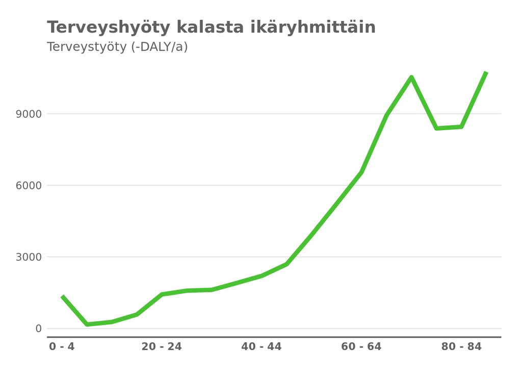

```r
tmp2 <- trim(oapply(BoDattr,c("Area","Age","Iter"),sum))
tmp2 <- tmp2[tmp2$Area=="Finland",]
ggplot(tmp2, aes(x=Age, y=-BoDattrResult, group=Area))+geom_line(size=2,colour="#48c232")+
  scale_x_discrete(breaks = levels(ages)[seq(1,length(ages),4)])+
  thlTheme()+
  labs(
    title="Terveyshyöty kalasta ikäryhmittäin",
    x="Ikäryhmä",
    subtitle="Terveystyöty (-DALY/a)",
    y=""
  )
```

```r
ggsave("Terveyshyöty kalasta ikäryhmittäin.svg")
```

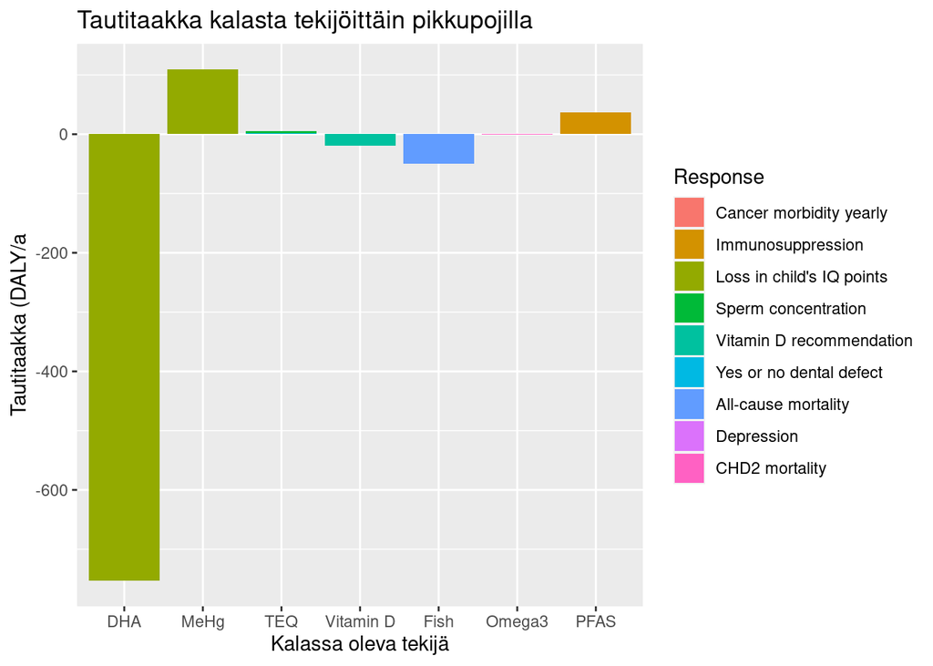

```r
ggplot(tmp[tmp$Age=="0 - 4" & tmp$Gender=="Male" , ],
       aes(x=Exposure_agent, weight=BoDattrResult, fill=Response),color="black")+geom_bar()+
  labs(
    title="Tautitaakka kalasta tekijöittäin pikkupojilla",
    x="Kalassa oleva tekijä",
    y="Tautitaakka (DALY/a"
  )
```

```r
ggsave("Tautitaakka kalasta tekijöittäin pikkupojilla Suomessa.svg")
```

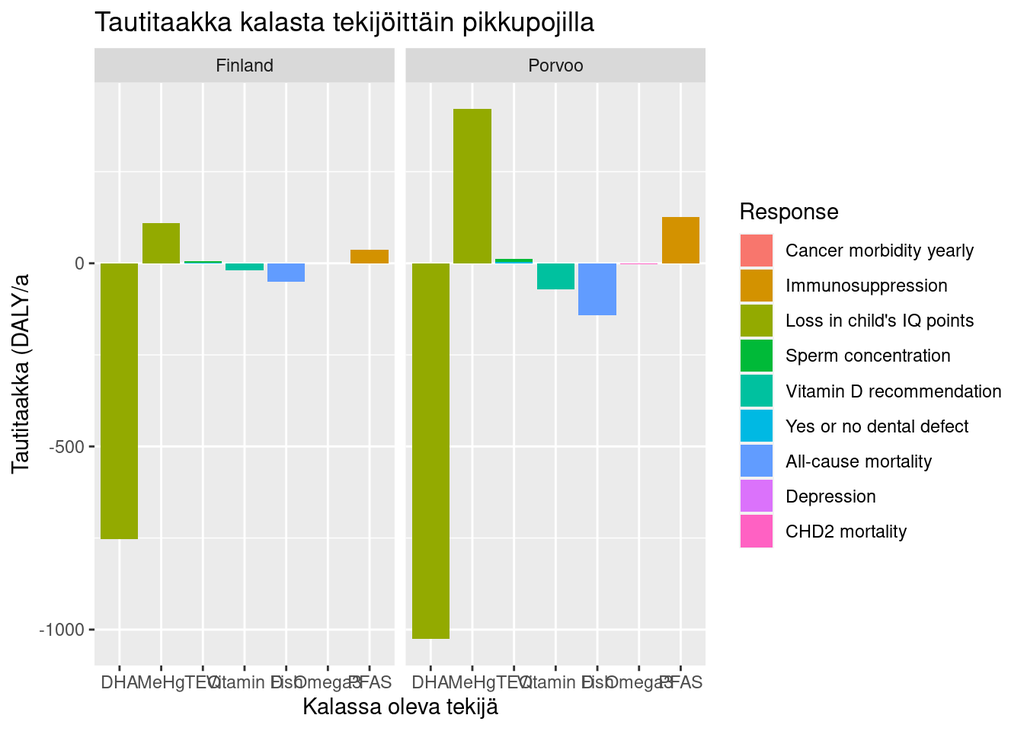

```r
tmp <- trim(BoDattr)
ggplot(tmp[tmp$Age=="0 - 4" & tmp$Gender=="Male" & tmp$Area!="Helsinki" , ],
       aes(x=Exposure_agent, weight=BoDattrResult, fill=Response),color="black")+geom_bar()+
  facet_wrap(~ Area)+
  labs(
    title="Tautitaakka kalasta tekijöittäin pikkupojilla",
    x="Kalassa oleva tekijä",
    y="Tautitaakka (DALY/a"
  )
```

```r
ggsave("Tautitaakka kalasta tekijöittäin pikkupojilla.svg")
```

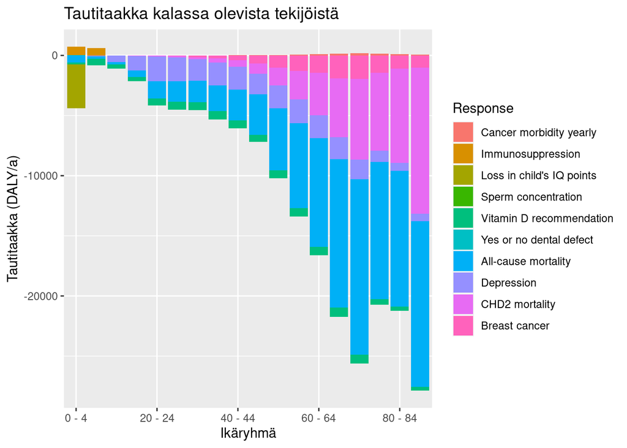

```r
ggplot(tmp, aes(x=Age, weight=BoDattrResult, fill=Response))+geom_bar(position="stack")+
  scale_x_discrete(breaks = levels(ages)[seq(1,length(ages),4)])+
  labs(
    title="Tautitaakka kalassa olevista tekijöistä",
    x="Ikäryhmä",
    y="Tautitaakka (DALY/a)"
  )
```

```r
ggsave("Tautitaakka kalassa olevista tekijöistä.svg")
```

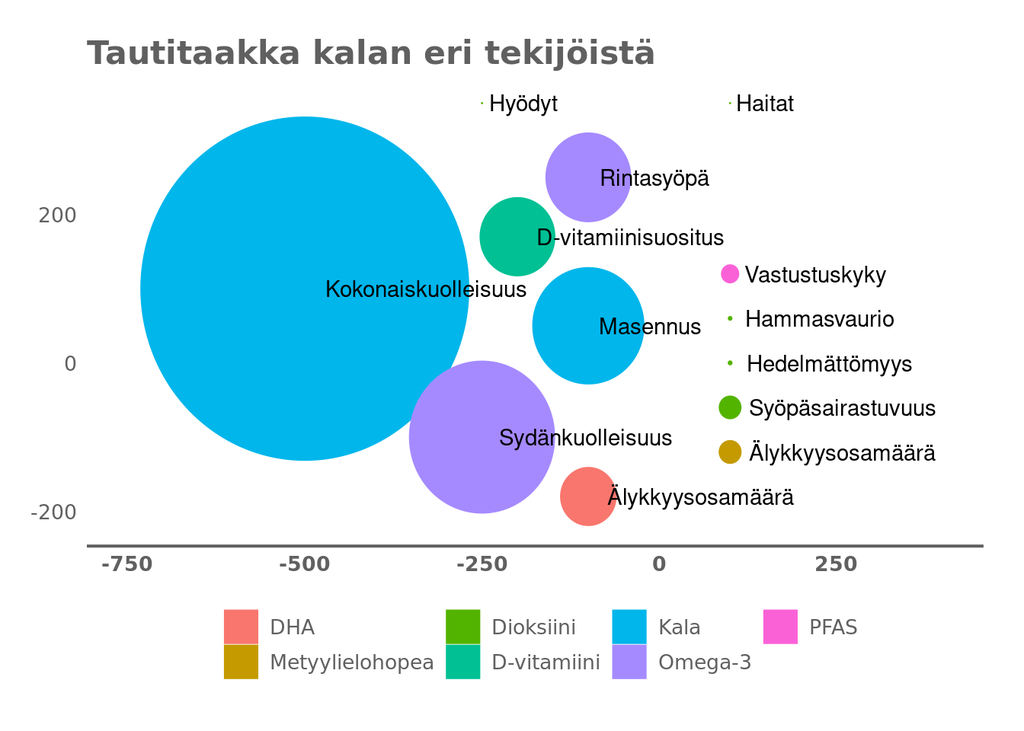

```r
tmp <- trim(oapply(BoDattr[BoDattr$Area=="Finland",],c("Response","Exposure_agent","Iter"),sum))
tmp$r <- sqrt(abs(tmp$BoDattrResult))
tmp$x0 <- c(-100, 100, 100, 100, 100,-200,-500,-100,-250,-100, 100)
tmp$y0 <- c(-180,-120, -60,   0,  60, 170, 100,  50,-100, 250, 120)
tmp <- rbind(tmp,data.frame(
  Response = c("Hyödyt","Haitat"),
  Exposure_agent= c("TEQ","TEQ"),
  BoDattrResult=c(0,0),
  r=c(0,0),
  x0=c(-250,100),
  y0=c(350,350)
))
ggplot(la(tmp), aes(x0=x0, y0=y0, r=r, fill=Altiste))+geom_circle(aes(color=Altiste))+
  geom_text(aes(x=x0, y=y0, label=Vaikutus), hjust=-0.1)+
  coord_cartesian(xlim=c(-750, 400))+
  thlTheme(
    legend.position ="bottom",
    show.grid.y=FALSE)+
  theme(
    axis.title=element_blank(),
    axis.text=element_blank(),
    axis.ticks=element_blank())+
  labs(
    title="Tautitaakka kalan eri tekijöistä",
    y=""
  )
```

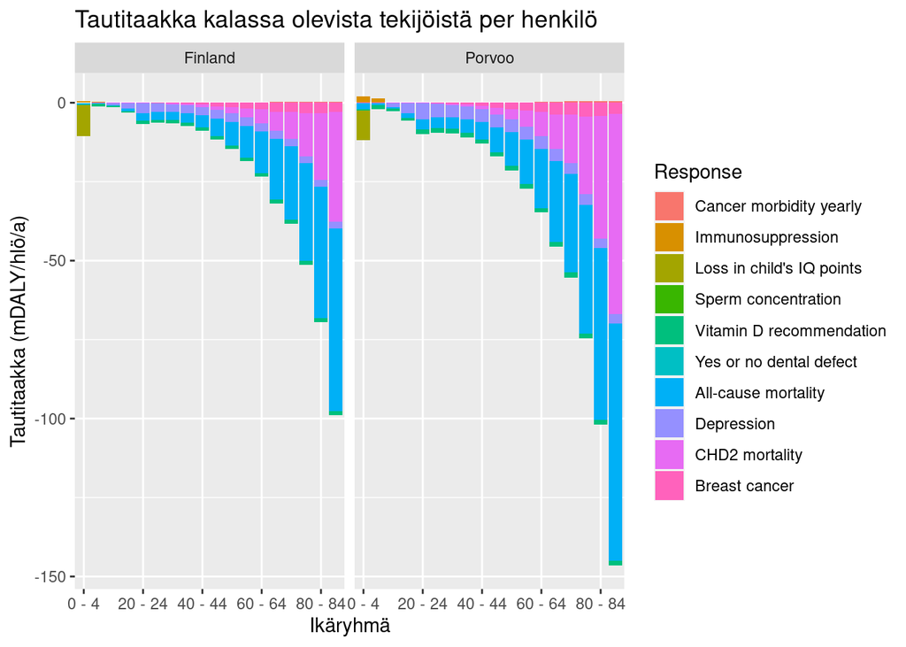

```r
ggsave("Suomen tautitaakka kalasta pallokuviona.svg", height=5, width = 9)

tmp <- BoDattr / population * 1000

p <- ggplot(trim(tmp[tmp$Area!="Helsinki",]), aes(x=Age, weight=Result, fill=Response))+geom_bar(position="stack")+
  scale_x_discrete(breaks = levels(ages)[seq(1,length(ages),4)])+
  labs(
    title="Tautitaakka kalassa olevista tekijöistä per henkilö",
    x="Ikäryhmä",
    y="Tautitaakka (mDALY/hlö/a)"
  ) + facet_wrap(~Area)
  oprint(p)
```

```r
  ggsave("Tautitaakka kalassa olevista tekijöistä per henkilö.svg")
```

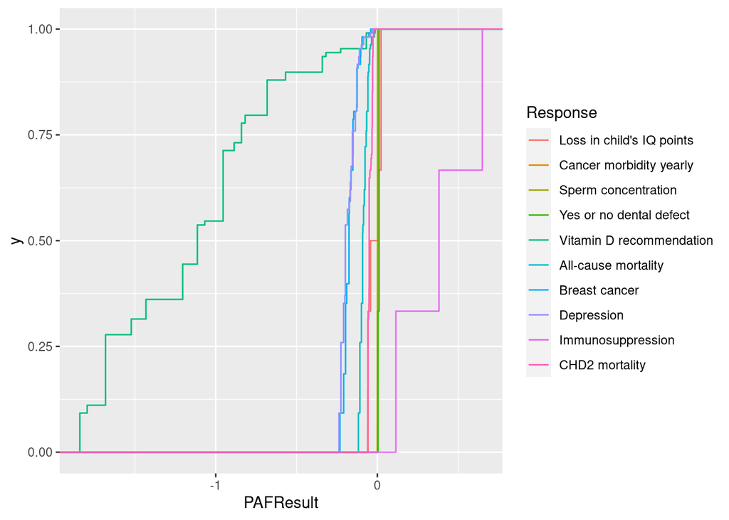

```r
  ggplot(trim(PAF), aes(x=PAFResult, colour=Response))+stat_ecdf()
```

```r
tmp <- expo_dir + Ovariable("limits", data=limits)
tmp <- tmp[!(tmp$Exposure_agent=="TEQ"&tmp$Scaling=="BW") & tmp$Exposcen=="BAU",]
tmp <- tmp[tmp$Area=="Finland",]
tmp$tst <- paste(tmp$Iter, tmp$Gender, tmp$Age)
#tst <- CollapseMarginal(tmp,"Age",fun="sample",
#  probs=list(Age=result(oapply(population[population$Age!="Undefined",],"Age",sum))))

# This Venn diagram produced the following numbers for the different subgroups
# no-RDI, no-TWI: 4184
# RDI only: 99
# TDI only: 1666
# Both RDI+TDI: 1251
# Total: 7200 (200 iterations, 2 Genders, 18 ages) # Actually Age should be collapsed, weighted by population.
# Not critical in Finland because so similar age group sizes. Besides reduces number of observations,
# and should be rerun with more iterations.
# the ovariable has 36000 rows: (in addition 5 Exposure_agents)
if(FALSE) {
ggVennDiagram(list(
  All = tmp$tst[tmp$Exposure_agent=="TEQ"],
#  MeHg = tmp$tst[tmp$Exposure_agent=="MeHg" & tmp$expo_dirResult > tmp$limitsResult],
#  TEQ = tmp$tst[tmp$Exposure_agent=="TEQ" & tmp$expo_dirResult > tmp$limitsResult],
#  PFAS = tmp$tst[tmp$Exposure_agent=="PFAS" & tmp$expo_dirResult > tmp$limitsResult],
#  VitD = tmp$tst[tmp$Exposure_agent=="Vitamin D" & tmp$expo_dirResult > tmp$limitsResult]
  RDI = tmp$tst[tmp$Type=="RDI" & tmp$expo_dirResult > tmp$limitsResult],
  TDI = tmp$tst[tmp$Type=="TDI" & tmp$expo_dirResult > tmp$limitsResult]
))
}
################ Insight network
#gr <- scrape(type="assessment")
#objects.latest("Op_en3861", "makeGraph") # [[Insight network]]
#gr <- makeGraph(gr)
#export_graph(gr, "ruori.svg")
#render_graph(gr) # Does not work: Error in generate_dot(graph) : object 'attribute' not found
##################### Diagnostics
#objects.latest("Op_en6007", code_name="diagnostics")
#print(showLoctable())
#print(showind())

# Self-made Venn diagram
# Take two circles:
# first is the unit circle x^2 + y^2 = 1
# second circle has centre at x-axis: (x-a)^2 + y^2 = r^2, r <= 1, 0 <= a <= r+1
# In other words, the other circle is never bigger and left to the first circle.
# This leads to a situation where the intercept always starts from (a-r,0) and goes to (min(1,a+r),0).

# Solve for the upper intercept point by replacing y^2:
# x^2 - 2ax + a^2 + (1 - x^2) = r^2
# x = (a^2 + 1 - r^2) / 2a

intercept <- function(a, r) {
  x <- (a^2 + 1 - r^2) / (2*a)
  y <- sqrt(1 - x^2)
  cat("intercept",x,y,"\n")
  return(c(x,y))
}

# Area of a segment of the unit circle integral sqrt(1 - x^2) dx = 1/2(sqrt(1-x^2)x+sin^-1(x))

# Area of segment of the other circle y = sqrt(r^2 - (x-a)^2)
# 1/2*((x-a)*sqrt(-a^2 + 2*a*x + r^2 - x^2) + r^2 * atan((x-a)/sqrt(r^2 - (a-x)^2)))

area <- function(a0, r0) {

  integ <- function(x, a, r) {
    out <- 1/2*((x-a)*sqrt(max(0,-a^2 + 2*a*x + r^2 - x^2)) + r^2 * atan((x-a)/sqrt(r^2 - (a-x)^2)))
    cat("integ",out,"\n")
    return(out)
  }
  A1 <- integ(intercept(a0,r0)[1], a0, r0) - integ(a0-r0, a0, r0) # left segment by the second circle
  A2 <- integ(min(1,a0+r0), 0, 1) - integ(intercept(a0,r0)[1], 0, 1) # right segment by the unit circle
  return(2*(A2 + A1)/pi) # returns the intercept area relative to unit circle
}
area(0.38,sqrt(1251/(1251+1666)))
```

```
## intercept 0.9414931 0.3370324
## integ 0.3155288
## integ -0.33683
## integ 0.7853982
## intercept 0.9414931 0.3370324
## integ 0.7721735
```

```
## [1] 0.4237236
```

```r
1251/(1251+1666)
```

```
## [1] 0.4288653
```

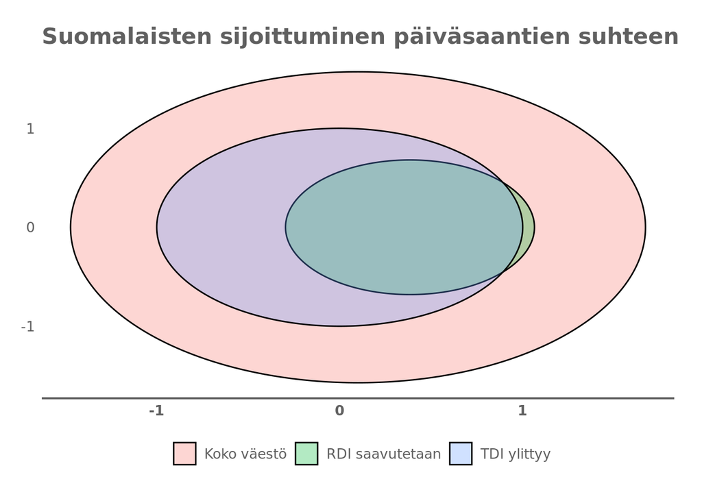

```r
df <- data.frame(
  x0=c(0,0.384,0.1),
  r=sqrt(c(1,(1251+99)/(1251+1666),(99+1251+1666+4184)/(1251+1666))),
  y0=c(0,0,0),
  Ryhmä=c("TDI ylittyy","RDI saavutetaan","Koko väestö")
)
ggplot(data=df, aes(x0=x0, y0=y0,r=r, fill=Ryhmä))+geom_circle(alpha=0.3)+
  theme(
    axis.title=element_blank(),
    axis.text=element_blank(),
    axis.ticks=element_blank())+
  thlTheme(
    legend.position ="bottom",
    show.grid.y = FALSE)+
  labs(
    title="Suomalaisten sijoittuminen päiväsaantien suhteen",
    y=""
  )
```

```r
ggsave("Venn_raja_arvoylitykset_kala_altistumisessa.svg", width=7, height=6)
```

```r
# Run all above
```